# Space-Time Prediction of Bike Share Demand

Palak Agarwal

November 13, 2020

## 1 Introduction

The San Francisco Municipal Transportation Agency (SFMTA) is a department of the City and County of San Francisco responsible for the management of all ground transportation in the city. The SFMTA has oversight over the Municipal Railway (Muni) public transit, as well as bicycling, paratransit, parking, traffic, walking, and taxis. In 2013 they partnered with public agencies to plan and implement the original Bay Area Bike Share pilot project and are now leading San Francisco’s efforts to work with the private sector partner to expand the system to over ten times its pilot size. They patnered with Lyft to expand the regional system which has since been re-branded with all-new equipment as Bay Wheels. In 2017, as independent stationless bikeshare emerged as a big new trend, they were among the first U.S. cities to create a regulatory and permitting framework to address this fast-moving phenomenon and insure that bikeshare in all its forms is safe, orderly and equitable for all San Franciscans.

One of the big operational challenges of bike share systems is “re-balancing” - getting bikes to stations that are anticipated to have demand but lack bikes. Figuring out how to do this is one of the keys to operating a successful system. With the introduction of the stationless bikeshare system the problem of re-balancing can be eliminated by a certain percentage. But it creates new problems as the bikes are further spread out and its harder to make sure that the bike is picked up. For the assignment, the data used is only from docked stations and does not include the stationless bikes.

For making the bike-share system more efficient i.e. to re-balance it many strategies can be introduced. I think the most effect strategy would be to use a reward system. If we know the capacity of a bike station and knew that the user was going to that station we could incentivize them to drop off the bike to another bike station or we could also incentivize them to use a bike which has not been touched for more than a two weeks. This will allow for an efficient demand and supply system.

Today’s trend is similar to the trend tomorrow and this week’s trend will be similar to next week trends. Hence, we will be able to predict how many bikes and from which station to high accuracy as you will see in the later in the model and assignment. If we know how many rides are going to take place, it is easier to use that data to manipulate which bikes are being used and which are not. For example, the Financial District of downtown SF is very busy and has many stations in the same block. If for some reason one station is more active than the other, we can use rewards to make people pick and drop bikes from different stations.

Lyft using its platform and app to show the users where the bikes are available so that can be used to make users pick up bikes that have not been touched for a while and also have them drop it off to locations where the demand is high and there is a shortage of bikes. SFMTA already has concessions for different individuals and communities which the bike share system can tap into as well. Knowing the capacity of a docking station will help us know if it has any open slots or not which can be a factor to provide users with offers to drop the bike off at other locations or if a busy dock is empty the user can be incentivized to drop off the bike there.

## 2.0 Setup

### 2.1 Libraries and themes

Let’s load relevant libraries and some graphic themes.

```r
## Setup
library(tidyverse)
library(sf)
library(lubridate)
library(tigris)
library(tidycensus)
library(viridis)
library(riem)
library(gridExtra)
library(knitr)
library(kableExtra)
library(RSocrata)
```

```r
library(FNN)

mapTheme <- function(base_size = 12) {
  theme(
    text = element_text( color = "black"),
    plot.title = element_text(size = 24,colour = "black"),
    plot.subtitle=element_text(face="italic"),
    plot.caption=element_text(hjust=0),
    axis.ticks = element_blank(),
    panel.background = element_blank(),axis.title = element_blank(),
    axis.text = element_blank(),
    axis.title.x = element_blank(),
    axis.title.y = element_blank(),
    panel.grid.minor = element_blank(),
    panel.border = element_rect(colour = "black", fill=NA, size=2)
  )
}

plotTheme <- function(base_size = 12) {
  theme(
    text = element_text( color = "black"),
    plot.title = element_text(size = 24,colour = "black"),
    plot.subtitle = element_text(face="italic"),
    plot.caption = element_text(hjust=0),
    axis.ticks = element_blank(),
    panel.background = element_blank(),
    panel.grid.major = element_line("grey60", size = 0.1),
    panel.grid.minor = element_blank(),
    panel.border = element_rect(colour = "black", fill=NA, size=2),
    strip.background = element_rect(fill = "grey60", color = "white"),
    strip.text = element_text(size=12),
    axis.title = element_text(size=12),
    axis.text = element_text(size=10),
    plot.background = element_blank(),
    legend.background = element_blank(),
    legend.title = element_text(colour = "black", face = "italic"),
    legend.text = element_text(colour = "black", face = "italic"),
    strip.text.x = element_text(size = 14)
  )
}

# Load Quantile break functions

qBr <- function(df, variable, rnd) {
  if (missing(rnd)) {
    as.character(quantile(round(df[[variable]],0),
                          c(.01,.2,.4,.6,.8), na.rm=T))
  } else if (rnd == FALSE | rnd == F) {
    as.character(formatC(quantile(df[[variable]]), digits = 3),
                 c(.01,.2,.4,.6,.8), na.rm=T)
  }
}

q5 <- function(variable) {as.factor(ntile(variable, 5))}

palette5 <- c("#eff3ff","#bdd7e7","#6baed6","#3182bd","#08519c")
palette4 <- c("#D2FBD4","#92BCAB","#527D82","#123F5A")
palette2 <- c("#6baed6","#08519c")

# Functions
nn_function <- function(measureFrom,measureTo,k) {
  measureFrom_Matrix <- as.matrix(measureFrom)
  measureTo_Matrix <- as.matrix(measureTo)
  nn <-
    get.knnx(measureTo, measureFrom, k)$nn.dist
  output <-
    as.data.frame(nn) %>%
    rownames_to_column(var = "thisPoint") %>%
    gather(points, point_distance, V1:ncol(.)) %>%
    arrange(as.numeric(thisPoint)) %>%
    group_by(thisPoint) %>%
    summarize(pointDistance = mean(point_distance)) %>%
    arrange(as.numeric(thisPoint)) %>%
    dplyr::select(-thisPoint) %>%
    pull()

  return(output)
}
```

### 2.2 Data Wrangling

Reading in the bike data.

```r
## Read data
sf_bike1 <- read.csv('Data/201803-fordgobike.csv')
sf_bike2 <- read.csv('Data/201804-fordgobike.csv')

sf_bike <- rbind(sf_bike1, sf_bike2)
glimpse(sf_bike)

sfCounty <-
  st_read("https://data.sfgov.org/api/geospatial/p5b7-5n3h?method=export&format=GeoJSON") %>%
  st_union() %>%
  st_transform('ESRI:102241')

neighborhoods <-
  st_read("https://data.sfgov.org/api/geospatial/pty2-tcw4?method=export&format=GeoJSON") %>%
  st_transform('ESRI:102241') %>%
  dplyr::select(-link)
```

After that we use the data to create bins of 15 and 60 minute intervals by rounding.

```r
sfBike <- sf_bike %>%
  mutate(interval60 = floor_date(ymd_hms(start_time), unit = "hour"),
         interval15 = floor_date(ymd_hms(start_time), unit = "15 mins"),
         week = week(interval60),
         dotw = wday(interval60, label=TRUE)) %>%
  filter(week < 15)
```

### 2.3 Census Data

For the analysis, I am using 2018 census data for San Francisco and Alameda county.

```r
# Install Census API Key
census_api_key("aea3dee2d96acb5101e94f3dcfa1b575f73d093a", overwrite = TRUE)

sfCensus <-
  get_acs(geography = "tract",
          variables = c("B01003_001", "B19013_001",
                        "B02001_002", "B08013_001",
                        "B08012_001", "B08301_001",
                        "B08301_010", "B01002_001"),
          year = 2018,
          state = 06,
          geometry = TRUE,
          county=c(001,075),
          output = "wide") %>%
  rename(Total_Pop =  B01003_001E,
         Med_Inc = B19013_001E,
         Med_Age = B01002_001E,
         White_Pop = B02001_002E,
         Travel_Time = B08013_001E,
         Num_Commuters = B08012_001E,
         Means_of_Transport = B08301_001E,
         Total_Public_Trans = B08301_010E) %>%
  select(Total_Pop, Med_Inc, White_Pop, Travel_Time,
         Means_of_Transport, Total_Public_Trans,
         Med_Age,
         GEOID, geometry) %>%
  mutate(Percent_White = White_Pop / Total_Pop,
         Mean_Commute_Time = Travel_Time / Total_Public_Trans,
         Percent_Taking_Public_Trans = Total_Public_Trans / Means_of_Transport) %>%
  st_transform('ESRI:102241')

sfTracts <-
  sfCensus %>%
  as.data.frame() %>%
  distinct(GEOID, .keep_all = TRUE) %>%
  select(GEOID, geometry) %>%
  st_sf
```

## 2.4 Connect census data to the the Bikeshare data

Now lets add the spatial information to our bikeshare data as origin and destination data, first joining the origin station, then the destination station to our census data.

```r
## Adding census data to bike data
sfBike_census <- st_join(sfBike %>%
                        filter(is.na(start_station_longitude) == FALSE &
                                 is.na(start_station_latitude) == FALSE &
                                 is.na(end_station_latitude) == FALSE  &
                                 is.na(end_station_longitude) == FALSE) %>%
                        st_as_sf(., coords = c("start_station_longitude", "start_station_latitude"), crs = 4326),
                      sfTracts %>%
                        st_transform(crs=4326),
                      join=st_intersects,
                          left = TRUE) %>%
  rename(Origin.Tract = GEOID) %>%
  mutate(start_station_longitude = unlist(map(geometry, 1)),
         start_station_latitude = unlist(map(geometry, 2)))%>%
  as.data.frame() %>%
  select(-geometry)%>%
  st_as_sf(., coords = c("end_station_longitude", "end_station_latitude"), crs = 4326) %>%
  st_join(., sfTracts %>%
            st_transform(crs=4326),
          join=st_intersects,
          left = TRUE) %>%
  rename(Destination.Tract = GEOID)  %>%
  mutate(end_station_longitude = unlist(map(geometry, 1)),
         end_station_latitude = unlist(map(geometry, 2)))%>%
  as.data.frame() %>%
  na.omit(Origin.Tract, Destination.Tract) %>%
  select(-geometry)
```

## 2.5 Weather Data

As weather plays an important factor in defining if one is likely to bike or not, e.g. “does precipitation appear to affect ridership during rush hour?”. So we import weather data from SFO airport and get temperature, wind speed, precipitation on an hourly basis and plot the temperature and precipitation trends over our study period.  
As you can see from the plot below, most days during the study months were pleasant and there wasnt much percipitation.

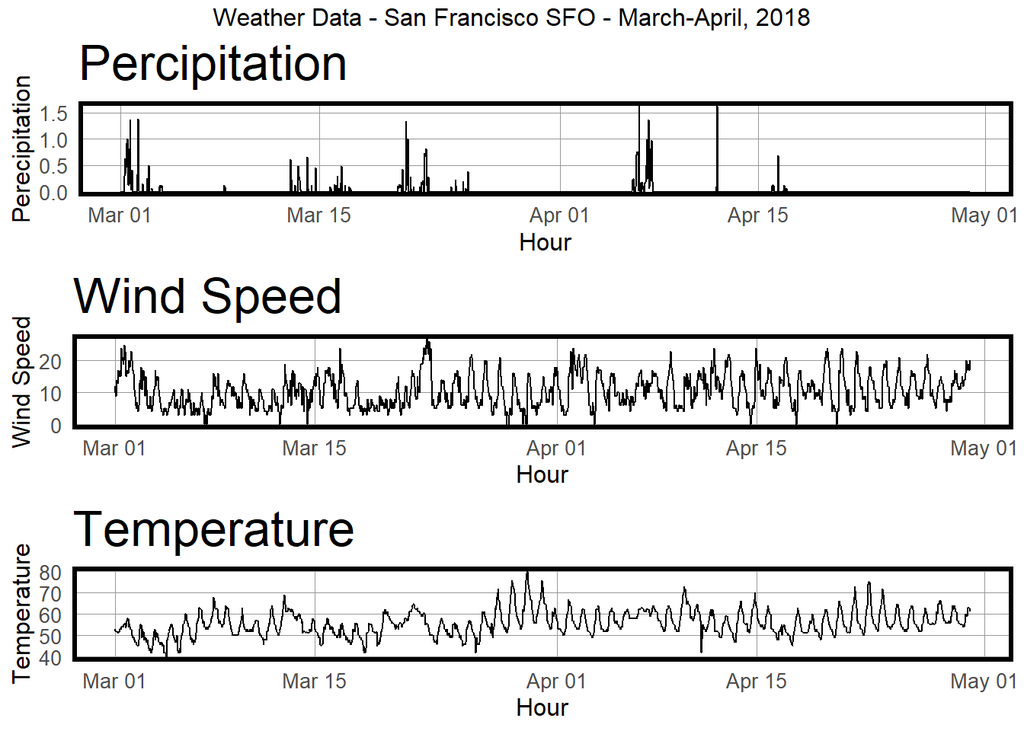

```r
## Weather Data

weather.Panel <-
  riem_measures(station = "SFO", date_start = "2018-03-01", date_end = "2018-04-30") %>%
  dplyr::select(valid, tmpf, p01i, sknt)%>%
  replace(is.na(.), 0) %>%
  mutate(interval60 = ymd_h(substr(valid,1,13))) %>%
  mutate(week = week(interval60),
         dotw = wday(interval60, label=TRUE)) %>%
  group_by(interval60) %>%
  summarize(Temperature = max(tmpf),
            Precipitation = sum(p01i),
            Wind_Speed = max(sknt)) %>%
  mutate(Temperature = ifelse(Temperature == 0, 42, Temperature))

grid.arrange(
  ggplot(weather.Panel, aes(interval60,Precipitation)) + geom_line() +
    labs(title="Percipitation", x="Hour", y="Perecipitation") + plotTheme(),
  ggplot(weather.Panel, aes(interval60,Wind_Speed)) + geom_line() +
    labs(title="Wind Speed", x="Hour", y="Wind Speed") + plotTheme(),
  ggplot(weather.Panel, aes(interval60,Temperature)) + geom_line() +
    labs(title="Temperature", x="Hour", y="Temperature") + plotTheme(),
  top="Weather Data - San Francisco SFO - March-April, 2018")
```

## 3 Data Exploration

We begin by examining the time and frequency components of our data.

First, we look at the overall time pattern - there is clearly a daily periodicity and there are lull periods on weekends.

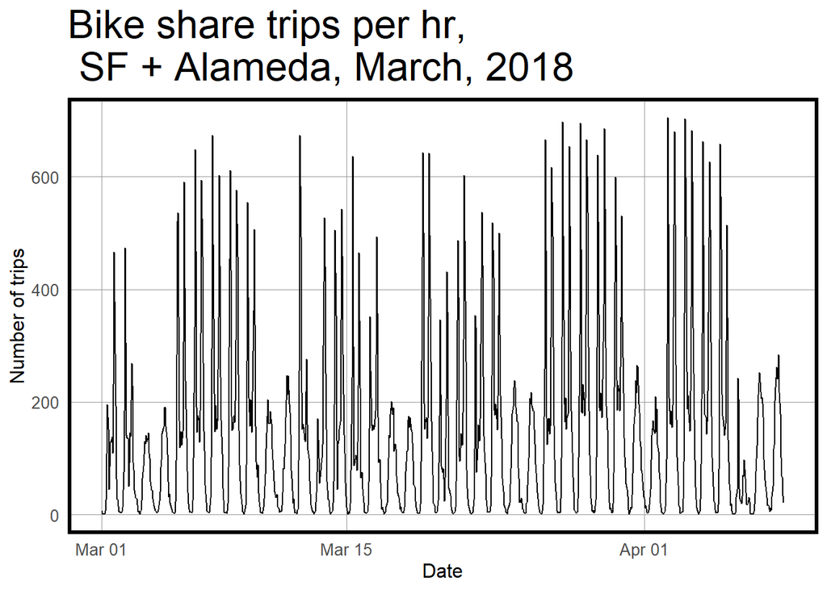

```r
ggplot(sfBike_census %>%
         group_by(interval60) %>%
         tally())+
  geom_line(aes(x = interval60, y = n))+
  labs(title="Bike share trips per hr,\n SF + Alameda, March, 2018",
       x="Date",
       y="Number of trips")+
  plotTheme()
```

The below plot shows the mean number of hourly trips is high during the morning and evening rush.

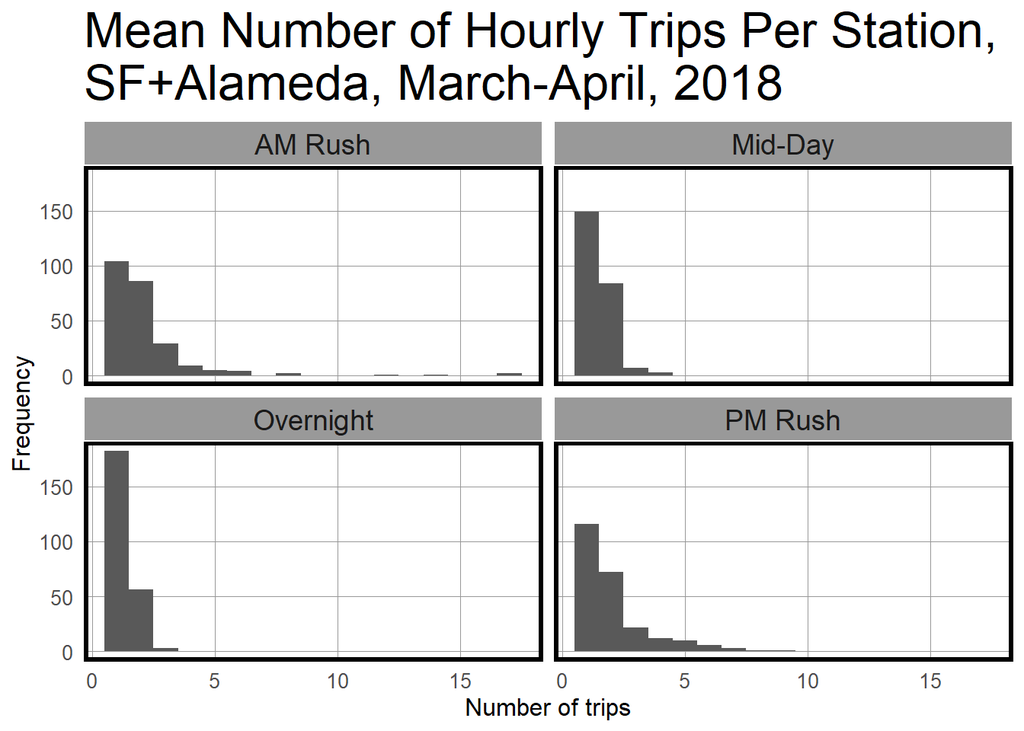

```r
## Mean number of hourly trips
sfBike_census %>%
  mutate(time_of_day = case_when(hour(interval60) < 7 | hour(interval60) > 18 ~ "Overnight",
                                 hour(interval60) >= 7 & hour(interval60) < 10 ~ "AM Rush",
                                 hour(interval60) >= 10 & hour(interval60) < 15 ~ "Mid-Day",
                                 hour(interval60) >= 15 & hour(interval60) <= 18 ~ "PM Rush"))%>%
  group_by(interval60, start_station_name, time_of_day) %>%
  tally()%>%
  group_by(start_station_name, time_of_day)%>%
  summarize(mean_trips = mean(n))%>%
  ggplot()+
  geom_histogram(aes(mean_trips), binwidth = 1)+
  labs(title="Mean Number of Hourly Trips Per Station,\nSF+Alameda, March-April, 2018",
       x="Number of trips",
       y="Frequency")+
  facet_wrap(~time_of_day)+
  plotTheme()
```

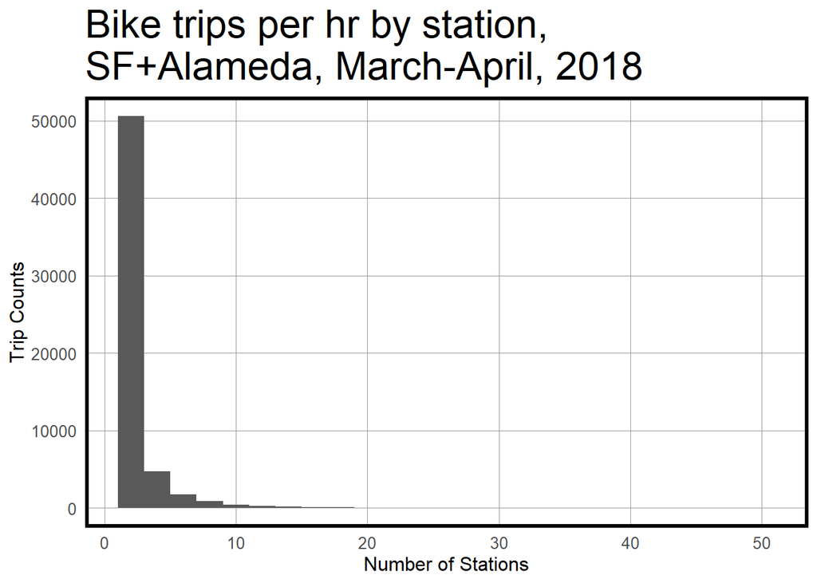

```r
## By station
ggplot(sfBike_census %>%
         group_by(interval60, start_station_name) %>%
         tally())+
  geom_histogram(aes(n), binwidth = 2)+
  labs(title="Bike trips per hr by station,\nSF+Alameda, March-April, 2018",
       x="Number of Stations",
       y="Trip Counts")+
  plotTheme()
```

The plot below shows that most bike trips are during the weekday during the morning and evening rush. A similar trend is seen in the days of the week - weekdays being busier than weekends.

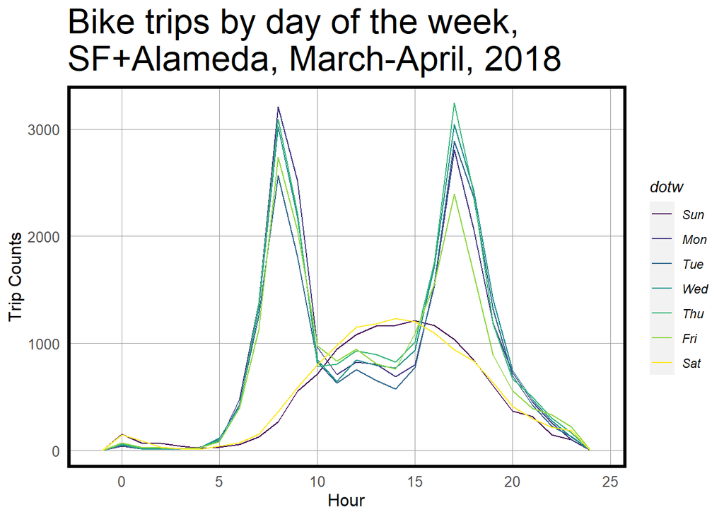

```r
## Number of trips by hr in a week
ggplot(sfBike_census %>% mutate(hour = hour(start_time)))+
  geom_freqpoly(aes(hour, color = dotw), binwidth = 1)+
  labs(title="Bike trips by day of the week,\nSF+Alameda, March-April, 2018",
       x="Hour",
       y="Trip Counts")+
  plotTheme()
```

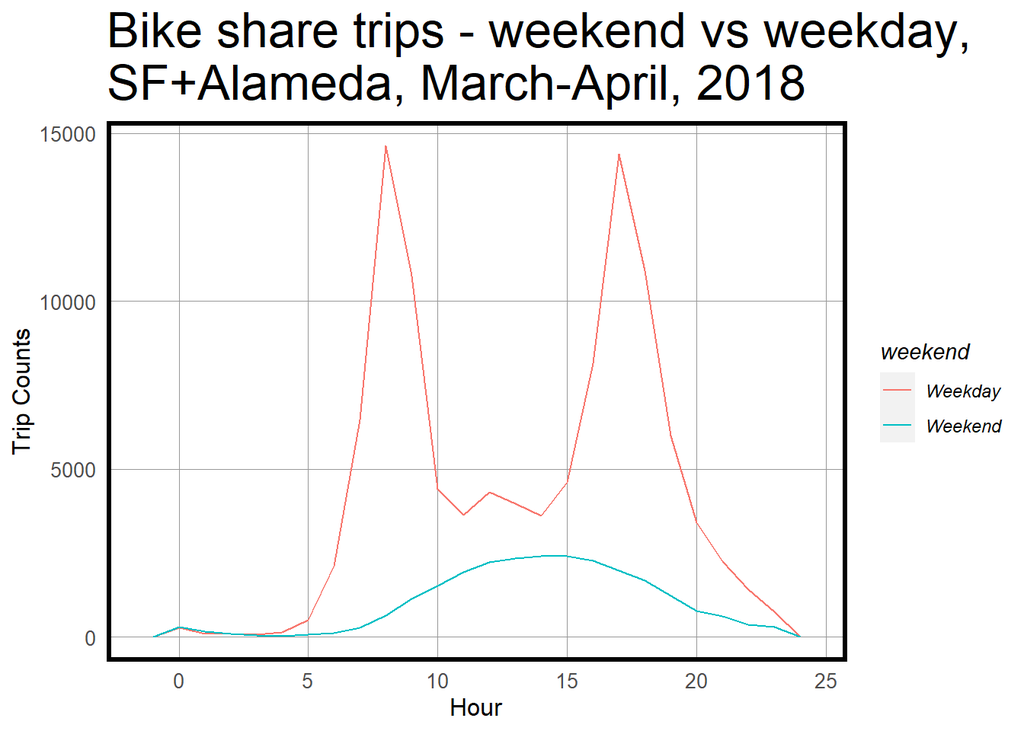

```r
## Number of trips weekday - weekend
ggplot(sfBike_census %>%
         mutate(hour = hour(start_time),
                weekend = ifelse(dotw %in% c("Sun", "Sat"), "Weekend", "Weekday")))+
  geom_freqpoly(aes(hour, color = weekend), binwidth = 1)+
  labs(title="Bike share trips - weekend vs weekday,\nSF+Alameda, March-April, 2018",
       x="Hour",
       y="Trip Counts")+
  plotTheme()
```

Here we the station on the census tracts to see which location has a higher demand than other. As evident in the maps, Financial District in SF sees the highest number of trips overall and peaks during morning and evening rush.

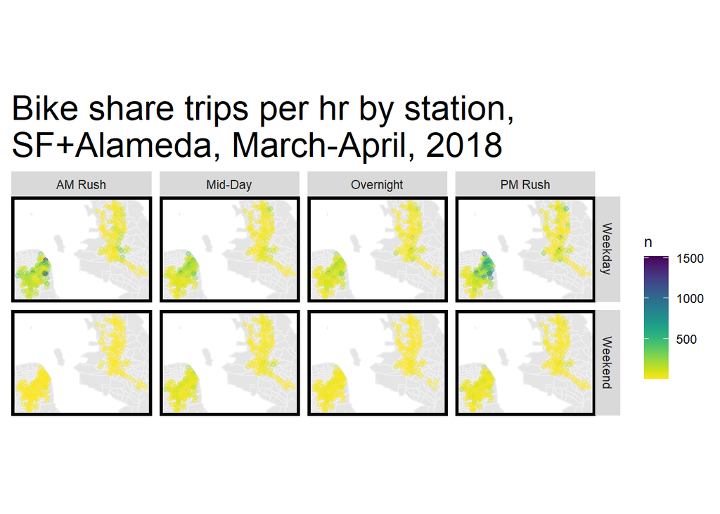

```r
## Rush by station on census tracts
ggplot()+
  geom_sf(data = sfTracts %>%
            st_transform(crs=4326), colour = '#efefef')+
  geom_point(data = sfBike_census %>%
               mutate(hour = hour(start_time),
                      weekend = ifelse(dotw %in% c("Sun", "Sat"), "Weekend", "Weekday"),
                      time_of_day = case_when(hour(interval60) < 7 | hour(interval60) > 18 ~ "Overnight",
                                              hour(interval60) >= 7 & hour(interval60) < 10 ~ "AM Rush",
                                              hour(interval60) >= 10 & hour(interval60) < 15 ~ "Mid-Day",
                                              hour(interval60) >= 15 & hour(interval60) <= 18 ~ "PM Rush"))%>%
               group_by(start_station_id, start_station_latitude, start_station_longitude, weekend, time_of_day) %>%
               tally(),
             aes(x=start_station_longitude, y = start_station_latitude, color = n),
             fill = "transparent", alpha = 0.4, size = 1.5)+
  scale_colour_viridis(direction = -1,
                       discrete = FALSE, option = "D")+
  ylim(min(sfBike_census$start_station_latitude), max(sfBike_census$start_station_latitude))+
  xlim(min(sfBike_census$start_station_longitude), max(sfBike_census$start_station_longitude))+
  facet_grid(weekend ~ time_of_day)+
  labs(title="Bike share trips per hr by station,\nSF+Alameda, March-April, 2018")+
  mapTheme()
```

## 4 Create Space-Time Panel

We create a time-series panel which basically is a unique combination of station id to the hour and day.This is done in order to create a “panel” data set where each time period in the study is represented by a row - whether an observation took place then or not. So if a station didn’t have any trips originating from it at a given hour, we still need a zero in that spot in the panel.

We start by determining the maximum number of combinations. Then we compare that to the actual number of combinations. We create an empty data frame study.panel, is created that has each unique space/time observations. This is done using the expand.grid function and unique. Along the way, we keep tabs on the number of rows our data have - nrow shows that the count is still correct. We then join the station name, tract and lat/lon and create the full panel by summarizing counts by station for each time interval, keep census info and lat/lon information along for joining later to other data.

```r
length(unique(sfBike_census$interval60)) * length(unique(sfBike_census$start_station_id))
```

```
## [1] 225747
```

```r
study.panel <-
  expand.grid(interval60=unique(sfBike_census$interval60),
              start_station_id = unique(sfBike_census$start_station_id)) %>%
  left_join(., sfBike_census %>%
              select(start_station_id, start_station_name, Origin.Tract, start_station_longitude, start_station_latitude )%>%
              distinct() %>%
              group_by(start_station_id) %>%
              slice(1))

nrow(study.panel)
```

```
## [1] 225747
```

```r
## Ride Panel
ride.panel <-
  sfBike_census %>%
  mutate(Trip_Counter = 1) %>%
  right_join(study.panel) %>%
  group_by(interval60, start_station_id, start_station_name, Origin.Tract, start_station_longitude, start_station_latitude) %>%
  summarize(Trip_Count = sum(Trip_Counter, na.rm=T)) %>%
  left_join(weather.Panel) %>%
  ungroup() %>%
  filter(is.na(start_station_id) == FALSE) %>%
  mutate(week = week(interval60),
         dotw = wday(interval60, label = TRUE)) %>%
  filter(is.na(Origin.Tract) == FALSE)

ride.panel <-
  left_join(ride.panel, sfCensus %>%
              as.data.frame() %>%
              select(-geometry), by = c("Origin.Tract" = "GEOID"))
```

## 5 Feature Engineering

### 5.1 Time Lags

As seen in the exploratory, morning and evening rush makes a difference in the demand for bikes. So here we create time lag variables which will give us additional information about the demand during a given time period.

```r
ride.panel <-
  ride.panel %>%
  arrange(start_station_id, interval60) %>%
  mutate(lagHour = dplyr::lag(Trip_Count,1),
         lag2Hours = dplyr::lag(Trip_Count,2),
         lag3Hours = dplyr::lag(Trip_Count,3),
         lag4Hours = dplyr::lag(Trip_Count,4),
         lag12Hours = dplyr::lag(Trip_Count,12),
         lag1day = dplyr::lag(Trip_Count,24)) %>%
  mutate(day = yday(interval60))

ride.panel <-
  ride.panel %>%
  mutate(X = start_station_longitude, Y = start_station_latitude )%>%
  st_as_sf(coords = c("X", "Y"), crs = 4326, agr = "constant") %>%
  st_transform('ESRI:102241')
```

```r
as.data.frame(ride.panel) %>%
  group_by(interval60) %>%
  summarise_at(vars(starts_with("lag"), "Trip_Count"), mean, na.rm = TRUE) %>%
  gather(Variable, Value, -interval60, -Trip_Count) %>%
  mutate(Variable = factor(Variable, levels=c("lagHour","lag2Hours","lag3Hours","lag4Hours",
                                              "lag12Hours","lag1day")))%>%
  group_by(Variable) %>%
  summarize(correlation = round(cor(Value, Trip_Count),2))
```

```
## # A tibble: 6 x 2
##   Variable   correlation
##   <fct>            <dbl>
## 1 lagHour           0.77
## 2 lag2Hours         0.4
## 3 lag3Hours         0.16
## 4 lag4Hours         0.03
## 5 lag12Hours       -0.25
## 6 lag1day           0.72
```

### 5.2 Exposure Features

```r
##Exposure Features

### Parks
parks_al <-
  read.socrata("https://data.oaklandca.gov/resource/kq8i-6bzk.json") %>%
  dplyr::select(Y = location_1.latitude, X = location_1.longitude) %>%
  na.omit() %>%
  st_as_sf(coords = c("X", "Y"), crs = 4326, agr = "constant") %>%
  st_transform('ESRI:102241') %>%
  mutate(Legend = "Park")

parks_sf <-
  st_read("C:/Users/agarw/Documents/MUSA508/MUSA508-Assignment3/Data/Recreation_and_Parks_Properties.csv") %>%
  dplyr::select(Y = Latitude, X = Longitude) %>%
  na.omit() %>%
  st_as_sf(coords = c("X", "Y"), crs = 4326, agr = "constant") %>%
  st_transform('ESRI:102241') %>%
  mutate(Legend = "Park")
parks <- rbind(parks_al, parks_sf)

ride.panel <-
  ride.panel %>%
  mutate(
    park_dist = nn_function(st_coordinates(ride.panel), st_coordinates(parks), 1))

## Distance to transit stop
sfo <- read.csv('C:/Users/agarw/Documents/MUSA508/MUSA-508-Assignment-1/Data/final_sfo_lines.csv')
x <- vector(mode='list', length = 105)
y <- vector(mode='list', length = 105)
spli <- strsplit(sfo$Location, ",")
for (val in spli){
  x <- append(x, val[[1]])
  y <- append(y, val[[2]])

}
sfo_new <-
  sfo %>%
  mutate(X = x[106:210],
         Y = y[106:210]) %>%
  dplyr::select(-Abbreviation, -Location, -Description)%>%
  st_as_sf(coords = c("X","Y"), crs = 4326, agr = "constant") %>%
  st_transform('ESRI:102241') %>%
  mutate(Legend = "Station")

ride.panel <-
  ride.panel %>%
  mutate(
    station_dist = nn_function(st_coordinates(ride.panel), st_coordinates(sfo_new), 1))

## Tourist spots
tourist_spots <- st_read('Data/attraction_point.geojson') %>%
  st_transform('ESRI:102241')

ride.panel <-
  ride.panel %>%
  mutate(
    tourist_dist = nn_function(st_coordinates(ride.panel), st_coordinates(tourist_spots), 1))

## Making the new features categorical
ride.panel <-
  ride.panel %>%
  mutate(Park = case_when(
    park_dist > 0 & park_dist <= 500 ~ "1",
    park_dist > 500 & park_dist <= 1000 ~ "2",
    park_dist > 1000 ~ "3"))

ride.panel <-
  ride.panel %>%
  mutate(Station = case_when(
    station_dist > 0 & station_dist <= 500 ~ "1",
    station_dist > 500 & station_dist <= 1000 ~ "3",
    station_dist > 1000 ~ "3"))

ride.panel <-
  ride.panel %>%
  mutate(Tourist = case_when(
    tourist_dist > 0 & tourist_dist <= 500 ~ "1",
    tourist_dist > 500 & tourist_dist <= 1000 ~ "2",
    tourist_dist > 1000 ~ "3"))
```

## 6.1 Linear Regressions

We split our data into a training and a test set. We create five linear models using the `lm` function.We create the models using our training data `ride.Train`. The first models include only temporal controls, but the later ones contain all of our lag information and other exposure features modeled in the previous section.

```r
## Regression
ride.Train <- filter(ride.panel, week <= 12)
ride.Test <- filter(ride.panel, week > 12)

### 5 regressions
reg1 <-
  lm(Trip_Count ~  hour(interval60) + dotw + Temperature,  data=ride.Train)

reg2 <-
  lm(Trip_Count ~  start_station_name + dotw + Temperature,  data=ride.Train)

reg3 <-
  lm(Trip_Count ~  start_station_name + hour(interval60) + dotw + Temperature + Precipitation,
     data=ride.Train)

reg4 <-
  lm(Trip_Count ~  start_station_name +  hour(interval60) + dotw + Temperature + Precipitation +
       lagHour + lag2Hours +lag3Hours + lag12Hours + lag1day,
     data=ride.Train)

reg5 <-
  lm(Trip_Count ~  start_station_name +  hour(interval60) + dotw + Temperature + Precipitation +
       lagHour + lag2Hours +lag3Hours + lag12Hours + lag1day + Park + Station + Tourist,
     data=ride.Train)
```

## 6.2 Predict for test data

```r
## Predicting
ride.Test.weekNest <-
  ride.Test %>%
  nest(-week)

model_pred <- function(dat, fit){
  pred <- predict(fit, newdata = dat)}

week_predictions <-
  ride.Test.weekNest %>%
  mutate(ATime_FE = map(.x = data, fit = reg1, .f = model_pred),
         BSpace_FE = map(.x = data, fit = reg2, .f = model_pred),
         CTime_Space_FE = map(.x = data, fit = reg3, .f = model_pred),
         DTime_Space_FE_timeLags = map(.x = data, fit = reg4, .f = model_pred),
         ETime_Space_FE_timeLags_Features = map(.x = data, fit = reg5, .f = model_pred)) %>%
  gather(Regression, Prediction, -data, -week) %>%
  mutate(Observed = map(data, pull, Trip_Count),
         Absolute_Error = map2(Observed, Prediction,  ~ abs(.x - .y)),
         MAE = map_dbl(Absolute_Error, mean, na.rm = TRUE),
         sd_AE = map_dbl(Absolute_Error, sd, na.rm = TRUE))

week_predictions
```

```
## # A tibble: 10 x 8
##     week data     Regression     Prediction  Observed Absolute_Error   MAE sd_AE
##    <dbl> <list>   <chr>          <list>      <list>   <list>         <dbl> <dbl>
##  1    13 <tibble~ ATime_FE       <dbl [40,3~ <dbl [4~ <dbl [40,338]> 0.849  1.68
##  2    14 <tibble~ ATime_FE       <dbl [40,8~ <dbl [4~ <dbl [40,824]> 0.789  1.50
##  3    13 <tibble~ BSpace_FE      <dbl [40,3~ <dbl [4~ <dbl [40,338]> 0.829  1.53
##  4    14 <tibble~ BSpace_FE      <dbl [40,8~ <dbl [4~ <dbl [40,824]> 0.770  1.39
##  5    13 <tibble~ CTime_Space_FE <dbl [40,3~ <dbl [4~ <dbl [40,338]> 0.826  1.52
##  6    14 <tibble~ CTime_Space_FE <dbl [40,8~ <dbl [4~ <dbl [40,824]> 0.775  1.37
##  7    13 <tibble~ DTime_Space_F~ <dbl [40,3~ <dbl [4~ <dbl [40,338]> 0.699  1.21
##  8    14 <tibble~ DTime_Space_F~ <dbl [40,8~ <dbl [4~ <dbl [40,824]> 0.613  1.06
##  9    13 <tibble~ ETime_Space_F~ <dbl [40,3~ <dbl [4~ <dbl [40,338]> 0.699  1.21
## 10    14 <tibble~ ETime_Space_F~ <dbl [40,8~ <dbl [4~ <dbl [40,824]> 0.613  1.06
```

## 6.3 Cross Validation

```r
## Cross validation
library(caret)

bikenetsample <- sample_n(ride.panel, 100000)%>%
  na.omit()

fitControl <- trainControl(method = "cv",
                           number = 100,
                           savePredictions = TRUE)

set.seed(1000)
# for k-folds CV

reg.cv <-
  train(Trip_Count ~ start_station_name +  hour(interval60) + dotw + Temperature + Precipitation +
          lagHour + lag2Hours +lag3Hours + lag12Hours + lag1day,
        data = bikenetsample,
        method = "lm",
        trControl = fitControl,
        na.action = na.pass)

reg.cv
```

```
## Linear Regression
##
## 99989 samples
##    11 predictor
##
## No pre-processing
## Resampling: Cross-Validated (100 fold)
## Summary of sample sizes: 98989, 98989, 98990, 98989, 98989, 98989, ...
## Resampling results:
##
##   RMSE      Rsquared   MAE
##   1.173384  0.4577107  0.6009281
##
## Tuning parameter 'intercept' was held constant at a value of TRUE
```

## 7 Accuracy

To check how accurately our model predicts the trip count we use the Mean Absolute Error(MAE). It is imporatant to be as accurate as we can be as that will define how well our re-balancing plan would work.

### 7.1 General Error Metrics

First lets see the MAE as a bar and line plot for the five different regressions. As you can see the regressions with time lags and the exposure features have lesser MAE and are closest to the observed pattern. From the line plot you can see that we are missing some peaks, so going back to find other features that affect the bike trip will make it better.

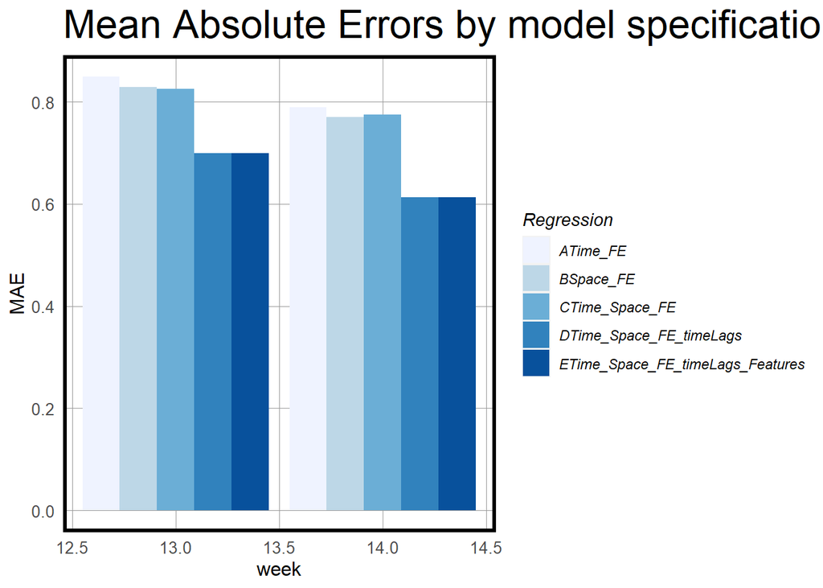

```r
week_predictions <-
  ride.Test.weekNest %>%
  mutate(ATime_FE = map(.x = data, fit = reg1, .f = model_pred),
         BSpace_FE = map(.x = data, fit = reg2, .f = model_pred),
         CTime_Space_FE = map(.x = data, fit = reg3, .f = model_pred),
         DTime_Space_FE_timeLags = map(.x = data, fit = reg4, .f = model_pred),
         ETime_Space_FE_timeLags_Features = map(.x = data, fit = reg5, .f = model_pred)) %>%
  gather(Regression, Prediction, -data, -week) %>%
  mutate(Observed = map(data, pull, Trip_Count),
         Absolute_Error = map2(Observed, Prediction,  ~ abs(.x - .y)),
         MAE = map_dbl(Absolute_Error, mean, na.rm = TRUE),
         sd_AE = map_dbl(Absolute_Error, sd, na.rm = TRUE))

## Bar plot
week_predictions %>%
  dplyr::select(week, Regression, MAE) %>%
  gather(Variable, MAE, -Regression, -week) %>%
  ggplot(aes(week, MAE)) +
  geom_bar(aes(fill = Regression), position = "dodge", stat="identity") +
  scale_fill_manual(values = palette5) +
  labs(title = "Mean Absolute Errors by model specification and week") +
  plotTheme()
```

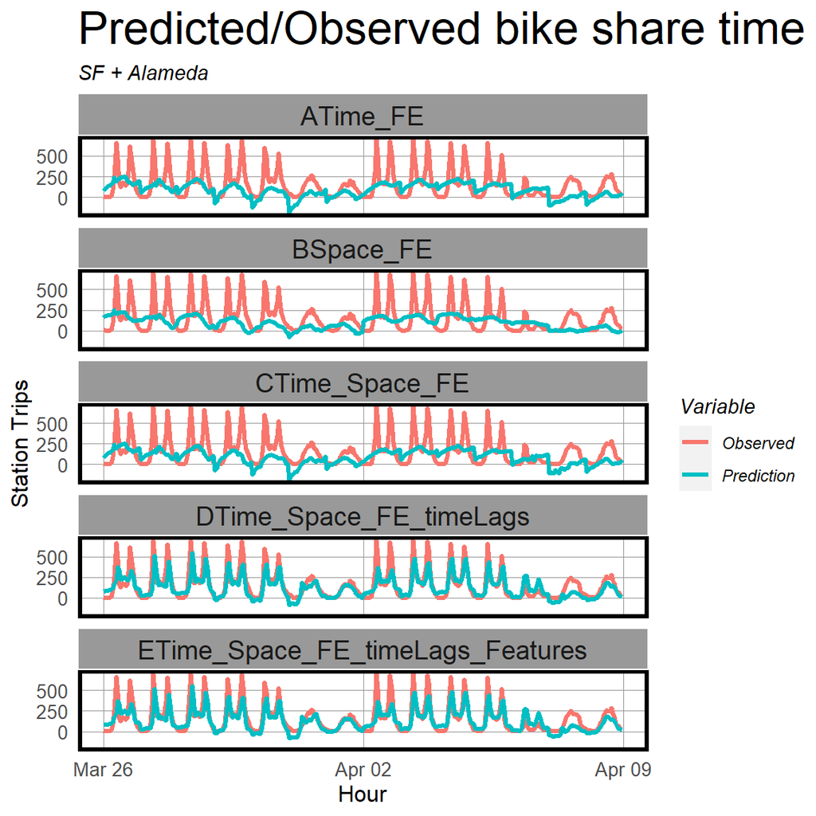

```r
## Graph
week_predictions %>%
  mutate(interval60 = map(data, pull, interval60),
         start_station_id = map(data, pull, start_station_id)) %>%
  dplyr::select(interval60, start_station_id, Observed, Prediction, Regression) %>%
  unnest() %>%
  gather(Variable, Value, -Regression, -interval60, -start_station_id) %>%
  group_by(Regression, Variable, interval60) %>%
  summarize(Value = sum(Value)) %>%
  ggplot(aes(interval60, Value, colour=Variable)) +
  geom_line(size = 1.1) +
  facet_wrap(~Regression, ncol=1) +
  labs(title = "Predicted/Observed bike share time series", subtitle = "SF + Alameda",  x = "Hour", y= "Station Trips") +
  plotTheme()
```

### 7.2 Specific Error Metrics

The highest error is in and around the Financial District in SF. That area has the highest bike ride number, hence why the error is also high. The CBD area is so important to SF that modeling some specific exposure features to that area might help improve the results.

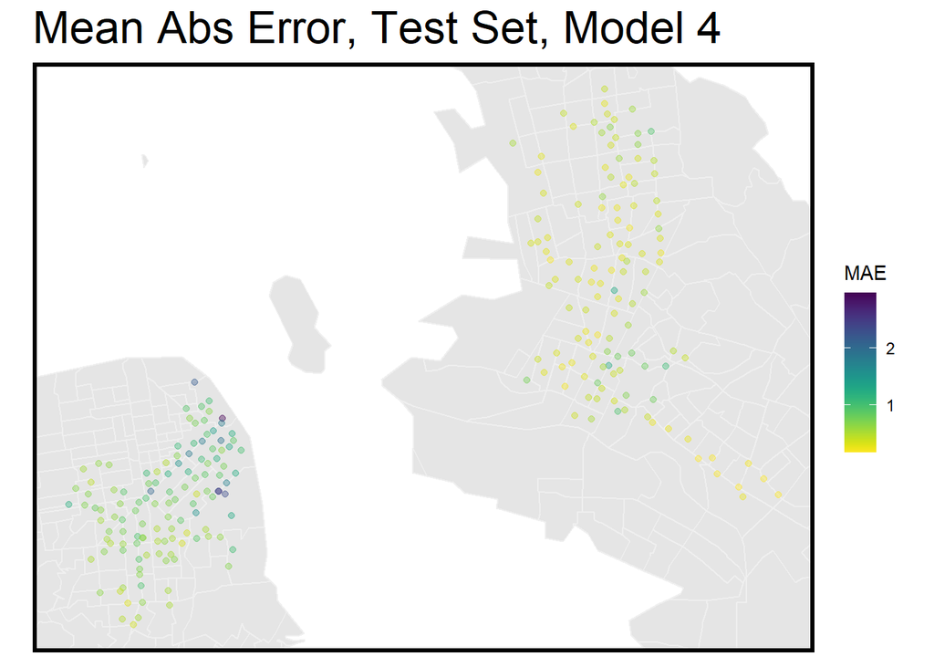

```r
## MAE by station
week_predictions %>%
  mutate(interval60 = map(data, pull, interval60),
         start_station_id = map(data, pull, start_station_id),
         start_station_latitude = map(data, pull, start_station_latitude),
         start_station_longitude = map(data, pull, start_station_longitude)) %>%
  select(interval60, start_station_id, start_station_longitude, start_station_latitude, Observed, Prediction, Regression) %>%
  unnest() %>%
  filter(Regression == "DTime_Space_FE_timeLags") %>%
  group_by(start_station_id, start_station_longitude, start_station_latitude) %>%
  summarize(MAE = mean(abs(Observed-Prediction), na.rm = TRUE))%>%
  ggplot(.)+
  geom_sf(data = sfTracts %>%
            st_transform(crs=4326), colour = '#efefef')+
  geom_point(aes(x = start_station_longitude, y = start_station_latitude, color = MAE),
             fill = "transparent", alpha = 0.4)+
  scale_colour_viridis(direction = -1,
                       discrete = FALSE, option = "D")+
  ylim(min(sfBike_census$start_station_latitude), max(sfBike_census$start_station_latitude))+
  xlim(min(sfBike_census$start_station_longitude), max(sfBike_census$start_station_longitude))+
  labs(title="Mean Abs Error, Test Set, Model 4")+
  mapTheme()
```

The ridership is high during the weekday as compared to the weekend, hence why the errors are higher in the weekday predictions. Similar observations can be made while looking at the time of the day i.e. the morning to night rush. This has been visualized both as a scatter plot and a spatial plot as seen below.

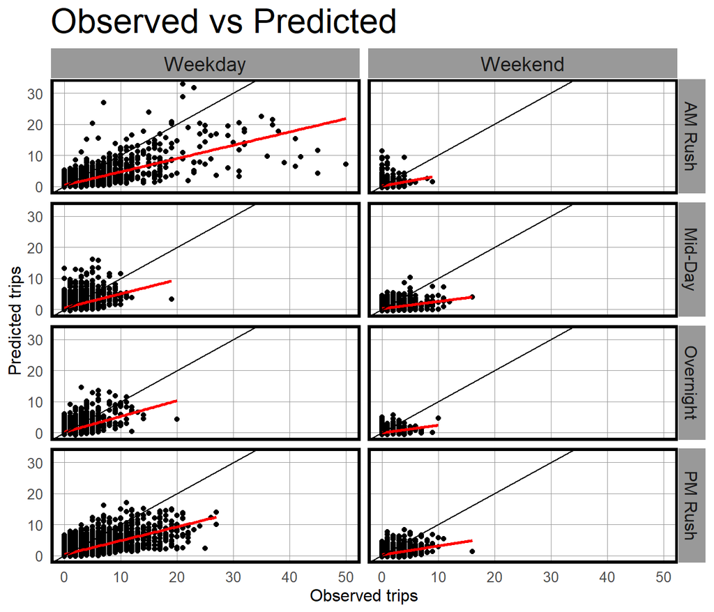

```r
## Scatterplot
week_predictions %>%
  mutate(interval60 = map(data, pull, interval60),
         start_station_id = map(data, pull, start_station_id),
         start_station_latitude = map(data, pull, start_station_latitude),
         start_station_longitude = map(data, pull, start_station_longitude),
         dotw = map(data, pull, dotw)) %>%
  select(interval60, start_station_id, start_station_longitude,
         start_station_latitude, Observed, Prediction, Regression,
         dotw) %>%
  unnest() %>%
  filter(Regression == "DTime_Space_FE_timeLags")%>%
  mutate(weekend = ifelse(dotw %in% c("Sun", "Sat"), "Weekend", "Weekday"),
         time_of_day = case_when(hour(interval60) < 7 | hour(interval60) > 18 ~ "Overnight",
                                 hour(interval60) >= 7 & hour(interval60) < 10 ~ "AM Rush",
                                 hour(interval60) >= 10 & hour(interval60) < 15 ~ "Mid-Day",
                                 hour(interval60) >= 15 & hour(interval60) <= 18 ~ "PM Rush"))%>%
  ggplot()+
  geom_point(aes(x= Observed, y = Prediction))+
  geom_smooth(aes(x= Observed, y= Prediction), method = "lm", se = FALSE, color = "red")+
  geom_abline(slope = 1, intercept = 0)+
  facet_grid(time_of_day~weekend)+
  labs(title="Observed vs Predicted",
       x="Observed trips",
       y="Predicted trips")+
  plotTheme()
```

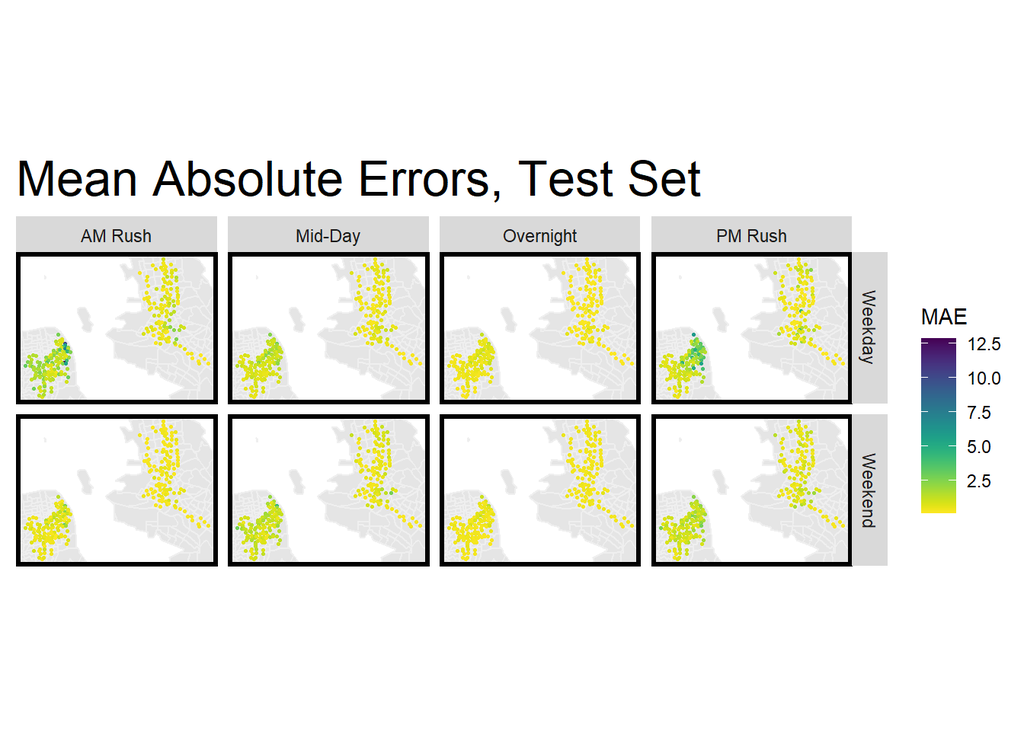

```r
##MAE by hour
week_predictions %>%
  mutate(interval60 = map(data, pull, interval60),
         start_station_id = map(data, pull, start_station_id),
         start_station_latitude = map(data, pull, start_station_latitude),
         start_station_longitude = map(data, pull, start_station_longitude),
         dotw = map(data, pull, dotw) ) %>%
  select(interval60, start_station_id, start_station_longitude,
         start_station_latitude, Observed, Prediction, Regression,
         dotw) %>%
  unnest() %>%
  filter(Regression == "DTime_Space_FE_timeLags")%>%
  mutate(weekend = ifelse(dotw %in% c("Sun", "Sat"), "Weekend", "Weekday"),
         time_of_day = case_when(hour(interval60) < 7 | hour(interval60) > 18 ~ "Overnight",
                                 hour(interval60) >= 7 & hour(interval60) < 10 ~ "AM Rush",
                                 hour(interval60) >= 10 & hour(interval60) < 15 ~ "Mid-Day",
                                 hour(interval60) >= 15 & hour(interval60) <= 18 ~ "PM Rush")) %>%
  group_by(start_station_id, weekend, time_of_day, start_station_longitude, start_station_latitude) %>%
  summarize(MAE = mean(abs(Observed-Prediction), na.rm = TRUE))%>%
  ggplot(.)+
  geom_sf(data = sfTracts %>%
            st_transform(crs=4326), colour = '#efefef')+
  geom_point(aes(x = start_station_longitude, y = start_station_latitude, color = MAE),
             fill = "transparent", size = 0.5, alpha = 1.5)+
  scale_colour_viridis(direction = -1,
                       discrete = FALSE, option = "D")+
  ylim(min(sfBike_census$start_station_latitude), max(sfBike_census$start_station_latitude))+
  xlim(min(sfBike_census$start_station_longitude), max(sfBike_census$start_station_longitude))+
  facet_grid(weekend~time_of_day)+
  labs(title="Mean Absolute Errors, Test Set")+
  mapTheme()
```

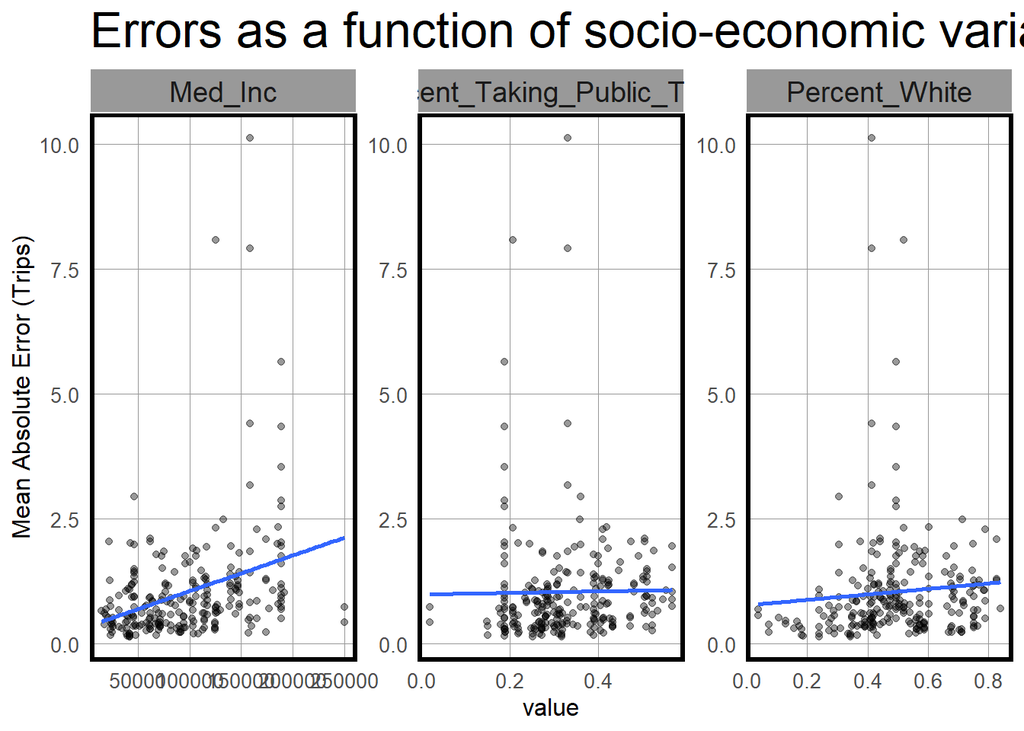

```r
## Error and census
week_predictions %>%
  mutate(interval60 = map(data, pull, interval60),
         start_station_id = map(data, pull, start_station_id),
         start_station_latitude = map(data, pull, start_station_latitude),
         start_station_longitude = map(data, pull, start_station_longitude),
         dotw = map(data, pull, dotw),
         Percent_Taking_Public_Trans = map(data, pull, Percent_Taking_Public_Trans),
         Med_Inc = map(data, pull, Med_Inc),
         Percent_White = map(data, pull, Percent_White)) %>%
  select(interval60, start_station_id, start_station_longitude,
         start_station_latitude, Observed, Prediction, Regression,
         dotw, Percent_Taking_Public_Trans, Med_Inc, Percent_White) %>%
  unnest() %>%
  filter(Regression == "DTime_Space_FE_timeLags")%>%
  mutate(weekend = ifelse(dotw %in% c("Sun", "Sat"), "Weekend", "Weekday"),
         time_of_day = case_when(hour(interval60) < 7 | hour(interval60) > 18 ~ "Overnight",
                                 hour(interval60) >= 7 & hour(interval60) < 10 ~ "AM Rush",
                                 hour(interval60) >= 10 & hour(interval60) < 15 ~ "Mid-Day",
                                 hour(interval60) >= 15 & hour(interval60) <= 18 ~ "PM Rush")) %>%
  filter(time_of_day == "AM Rush") %>%
  group_by(start_station_id, Percent_Taking_Public_Trans, Med_Inc, Percent_White) %>%
  summarize(MAE = mean(abs(Observed-Prediction), na.rm = TRUE))%>%
  gather(-start_station_id, -MAE, key = "variable", value = "value")%>%
  ggplot(.)+
  #geom_sf(data = sfCensus, color = "grey", fill = "transparent")+
  geom_point(aes(x = value, y = MAE), alpha = 0.4)+
  geom_smooth(aes(x = value, y = MAE), method = "lm", se= FALSE)+
  facet_wrap(~variable, scales = "free")+
  labs(title="Errors as a function of socio-economic variables",
       y="Mean Absolute Error (Trips)")+
  plotTheme()
```

Last lets look at the trip count by station as an animation for one week during March.

[figure not shown]

```r
## Animation

library(gganimate)
library(gifski)

week11 <-
  filter(sfBike_census , week == 11)

week11.panel <-
  expand.grid(
    interval15 = unique(week11$interval15),
    Pickup.Census.Tract = unique(sfBike_census$start_station_id))

ride.animation.data <-
  mutate(week11, Trip_Counter = 1) %>%
  select(interval15, start_station_id, start_station_longitude, start_station_latitude, Trip_Counter) %>%
  group_by(interval15, start_station_id, start_station_longitude, start_station_latitude) %>%
  summarize(Trip_Count = sum(Trip_Counter, na.rm=T)) %>%
  ungroup() %>%
  mutate(Trips = case_when(Trip_Count == 0 ~ "0 trips",
                           Trip_Count > 0 & Trip_Count <= 2 ~ "0-2 trips",
                           Trip_Count > 2 & Trip_Count <= 5 ~ "2-5 trips",
                           Trip_Count > 5 & Trip_Count <= 10 ~ "5-10 trips",
                           Trip_Count > 10 & Trip_Count <= 15 ~ "10-15 trips",
                           Trip_Count > 15 ~ "15+ trips")) %>%
  mutate(Trips  = fct_relevel(Trips, "0 trips","0-2 trips","2-5 trips",
                              "5-10 trips","10-15 trips","15+ trips"))

rideshare_animation <-
  ggplot()+
  geom_sf(data = sfTracts %>%
            st_transform(crs=4326), colour = '#efefef')+
  geom_point(data = ride.animation.data,
             aes(x = start_station_longitude, y = start_station_latitude, fill = Trips), size = 0.5, alpha = 1.5) +
  scale_colour_manual(values = palette5) +
  labs(title = "Rideshare pickups for one week in March 2018",
       subtitle = "15 minute intervals: {current_frame}") +
  transition_manual(interval15) +
  mapTheme()

animate(rideshare_animation, duration=20, renderer = gifski_renderer())
```